# R for Beginners - R for Finance Code File-1

This R code book written by [Rohit Dhankar](https://github.com/RohitDhankar) . GitHub - https://github.com/RohitDhankar

Code and Data > https://github.com/RohitDhankar/R-Beginners-Online-Virtual-Learning-Session

Good practice to keep track of current Working Directory , list all Objects in R ENVIRONMENT - specially so when committing changes to Git or any other version control Remote directory.

# R for Finance

A univariate data set having ONE Variable that varies as time passes is a TIME SERIES.  
Most data sets used for Machine Learning or Advanced Statistics have Multivariate Data.

TIME SERIES data is used as inferential and predictive data for various Business  
functions. Forecasting the Weather phenomenon for Agri based business.  
Forecasting usage of Pesticides , onset of Rains etc etc .

Within FINANCE usage is for Predicting STOCK ASSET VALUEs and also NAV’s  
of Mutual Funds.

```r
library("forecast");
library("ggplot2");
library("ggfortify")
library("tseries")
```

```r
# Set Seed -- ensure reproducible results
set.seed(123)
infy_df <- read.csv("~/Desktop/R_Own/R_Finance/DATA_Files/INFY.csv")
str(infy_df)
```

```
'data.frame':   494 obs. of  1 variable:
 $ Close.Price: num  1176 1135 1150 1092 1086 ...
```

```r
summary(infy_df)
```

```
  Close.Price
 Min.   : 911.1
 1st Qu.: 982.0
 Median :1049.1
 Mean   :1060.4
 3rd Qu.:1134.1
 Max.   :1267.6
```

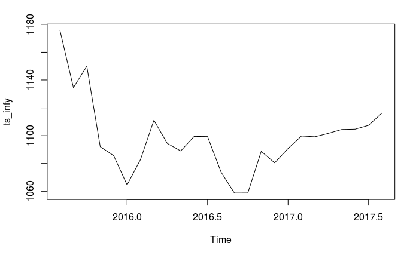

```r
#start_date <- infy_df$Date[1] ## [1] 19-Aug-2015
#len_df<-length(infy_df$Date)
#end_date <-infy_df$Date[len_df] ## [1] 17-Aug-2017
# Convert DF to TS
#ts_infy <-ts(infy_df, start = start_date, end = end_date,  frequency = 12) #
ts_infy <-ts(infy_df, start = c(2015,8), end =  c(2017,8),  frequency = 12) #
plot(ts_infy)
```

```r
#
#
```

```r
#?ts()
# frequency ---
# the number of observations per unit of time.
# deltat    ---
# the fraction of the sampling period between successive observations; e.g., 1/12 for monthly data. Only one of frequency or deltat should be provided.
#
ts_infy1 <-ts(infy_df, start = c(2015,8), end =  c(2017,8), frequency = 24,names = "NSE-INFY-STOCK_PRICE_DAILY_CLOSING") #
#
str(ts_infy1);summary(ts_infy1)
```

```
 Time-Series [1:49] from 2015 to 2017: 1176 1135 1150 1092 1086 ...
   Min. 1st Qu.  Median    Mean 3rd Qu.    Max.
   1059    1095    1107    1117    1141    1182
```

```r
#
typeof(ts_infy1) ## [1] "double"
```

```
[1] "double"
```

```r
#
typeof(ts_infy) ## [1] "double"
```

```
[1] "double"
```

```r
#
class(ts_infy)
```

```
[1] "ts"
```

```r
#
head(ts_infy1);head(time(ts_infy1));tail(time(ts_infy1))
```

```
Time Series:
Start = c(2015, 8)
End = c(2015, 13)
Frequency = 24
[1] 1175.55 1134.55 1149.90 1092.05 1085.65 1064.60
Time Series:
Start = c(2015, 8)
End = c(2015, 13)
Frequency = 24
[1] 2015.292 2015.333 2015.375 2015.417 2015.458 2015.500
Time Series:
Start = c(2017, 3)
End = c(2017, 8)
Frequency = 24
[1] 2017.083 2017.125 2017.167 2017.208 2017.250 2017.292
```

```r
# Head of TS # view Head - sampled times # view Tail of sampled times
dim(ts_infy1);
```

[output not shown]

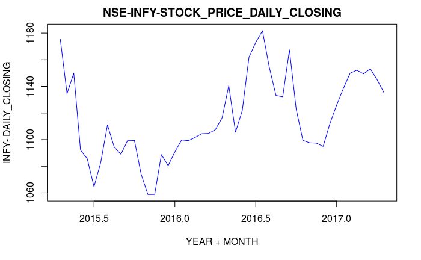

```r
#
#tsdisplay(ts_infy1)
#
plot.ts(ts_infy1,main="NSE-INFY-STOCK_PRICE_DAILY_CLOSING",col="blue",xlab="YEAR + MONTH",ylab="INFY- DAILY_CLOSING")
```

# STATIONARY TIME SERIES :-

We need to make the TIME SERIES Stationary if it is Not already so.  
TBD —- WIP — ARMA and ARIMA models

# ARMA(p,q)

TBD ——-

# Auto Regressive Integrated Moving Averages (ARIMA)

TBD ——-

# Decomposition of TIME SERIES :-

" to construct, from an observed time series, a number of  
component series (that could be used to reconstruct the original by additions  
or multiplications) where each of these has a certain characteristic or type of behaviour.

SOURCE – WIKI – https://en.wikipedia.org/wiki/Decomposition_of_time_series

```r
head(ts_infy1);head(time(ts_infy1));tail(time(ts_infy1))
```

```
Time Series:
Start = c(2015, 8)
End = c(2015, 13)
Frequency = 24
[1] 1175.55 1134.55 1149.90 1092.05 1085.65 1064.60
Time Series:
Start = c(2015, 8)
End = c(2015, 13)
Frequency = 24
[1] 2015.292 2015.333 2015.375 2015.417 2015.458 2015.500
Time Series:
Start = c(2017, 3)
End = c(2017, 8)
Frequency = 24
[1] 2017.083 2017.125 2017.167 2017.208 2017.250 2017.292
```

```r
# Head of TS # view Head - sampled times # view Tail of sampled times
```

Various Sources —

STACK_EXCHANGE – https://stats.stackexchange.com/questions/9506/stl-trend-of-time-series-using-r?rq=1

STACK_EXCHANGE – https://stats.stackexchange.com/questions/85987/which-is-better-stl-or-decompose